# What Makes Oregon Wine Unique?

04/16/2020

## Pinot Noir !!!

### Right??

But wait …is there evidence?

## Top 5 wine varieties on the west coast

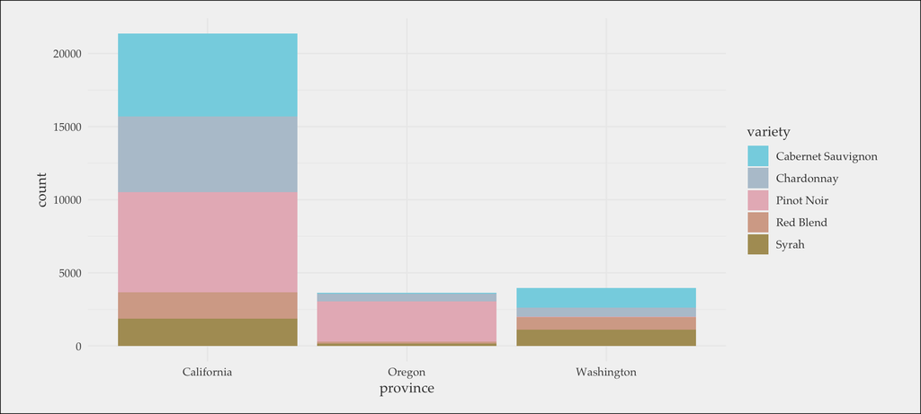

## Wines at 98 points or higher on the west coast

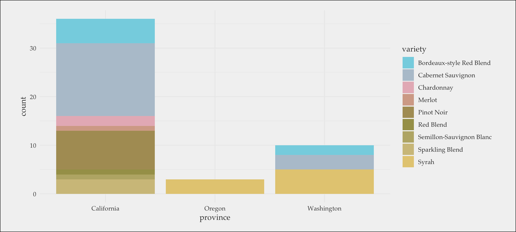

## Oregon’s Top wines

| winery | variety | points | price |
| --- | --- | --- | --- |
| Cayuse | Syrah | 99 | 75 |
| Cayuse | Syrah | 99 | 75 |
| Cayuse | Syrah | 98 | 75 |
| Cayuse | Cabernet Sauvignon | 97 | 90 |
| Cayuse | Syrah | 97 | 85 |
| Cayuse | Cabernet Sauvignon | 97 | 80 |
| Ken Wright | Pinot Noir | 97 | 65 |

## So what really makes us unique?

## Different from California Pinot…

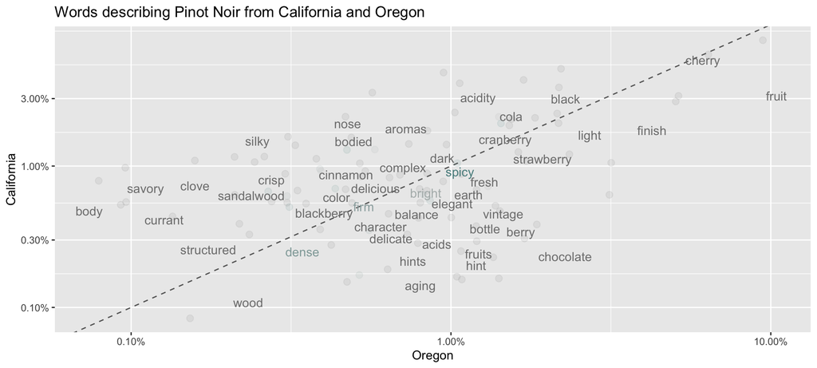

## Different from French Burgundy

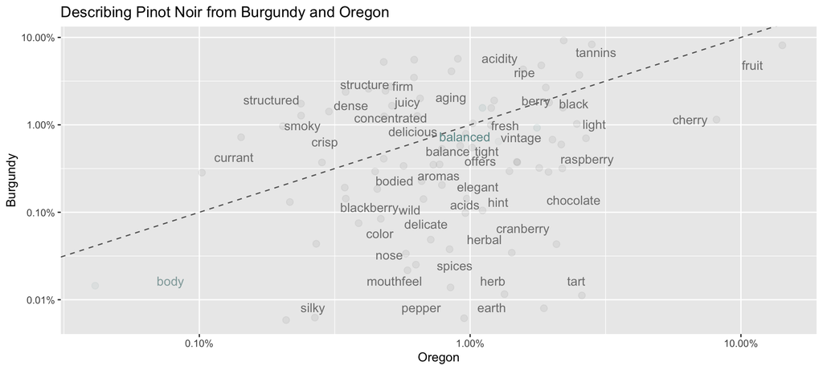

## Unique Oregon pinot descriptors (compared to California)

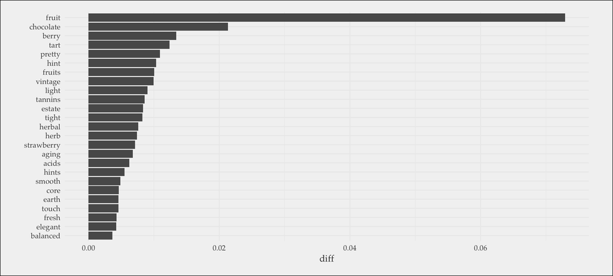

## Unique Oregon pinot descriptors (compared to Burgundy)

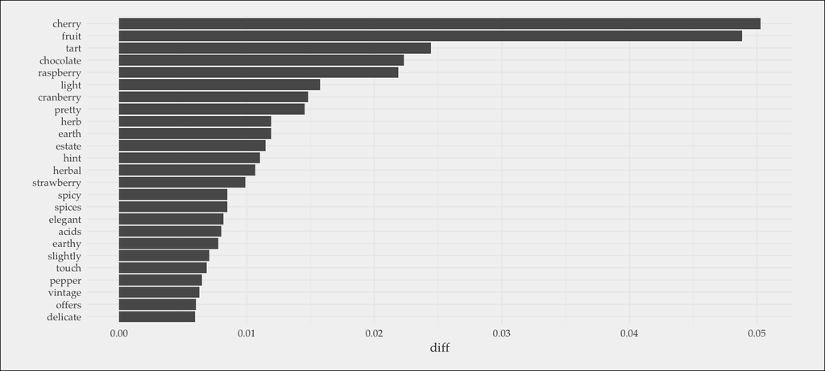

## Rating oregon flavors

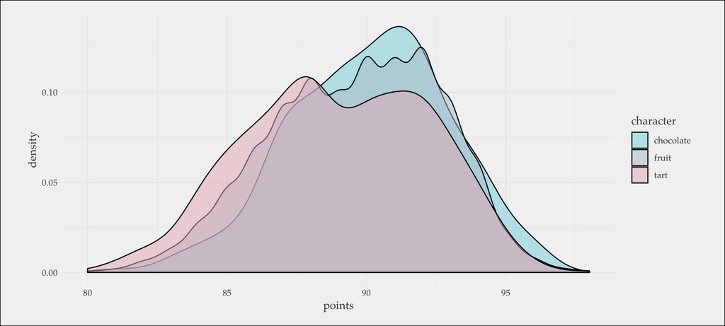

## A different view…

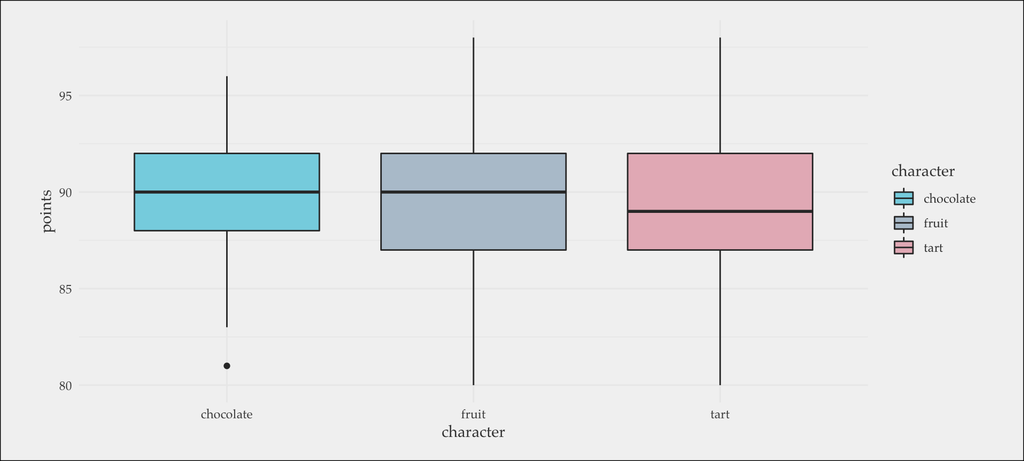

## Words with highest prices from Oregon Pinots

| word | avg_points | avg_price |
| --- | --- | --- |
| dense | 92.29231 | 57.83077 |
| savory | 91.09524 | 56.66667 |
| clove | 90.46667 | 55.46667 |
| currant | 90.33333 | 54.91667 |
| spices | 90.92357 | 54.13376 |
| complexity | 91.00885 | 54.08850 |
| dark | 91.19101 | 53.19663 |
| complex | 91.52985 | 53.03731 |
| sandalwood | 90.66667 | 52.60000 |
| structure | 91.13699 | 52.49315 |

## Maybe some of these terms hang together?

Let’s run a principle component analysis.

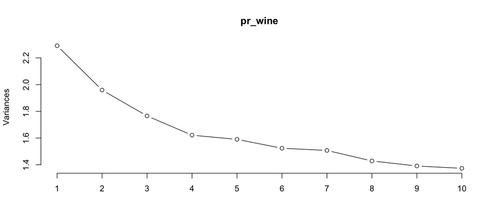

## Principle Component 1

| word | PC1 |
| --- | --- |
| black | 0.3896876 |
| dark | 0.2941987 |
| cherry | 0.2828796 |
| tart | -0.2704984 |
| cranberry | -0.2359813 |

## Principle Component 2

| word | PC2 |
| --- | --- |
| rose | -0.2886524 |
| fruit | 0.2863733 |
| cranberry | 0.2227294 |
| raspberries | -0.2220672 |
| elegant | -0.2146210 |

## Principle Component 3

| word | PC3 |
| --- | --- |
| fruits | -0.2884160 |
| cherry | 0.2872082 |
| fruit | 0.2832806 |
| earthy | -0.2642548 |
| herbal | -0.2484019 |

## Principle Component 4

| word | PC4 |
| --- | --- |
| smooth | -0.2685517 |
| herb | 0.2555363 |
| earth | 0.2078206 |
| dried | 0.1896823 |
| fruits | -0.1853882 |

## Beyond words…

## Variation in points by province

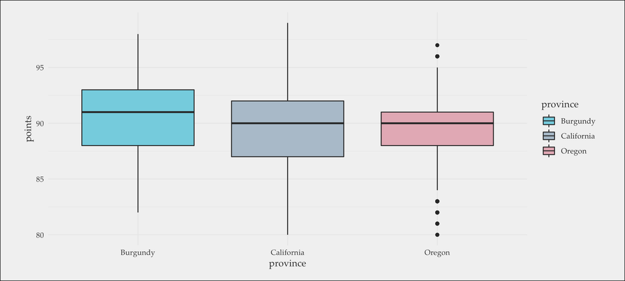

## More consistent Pinots

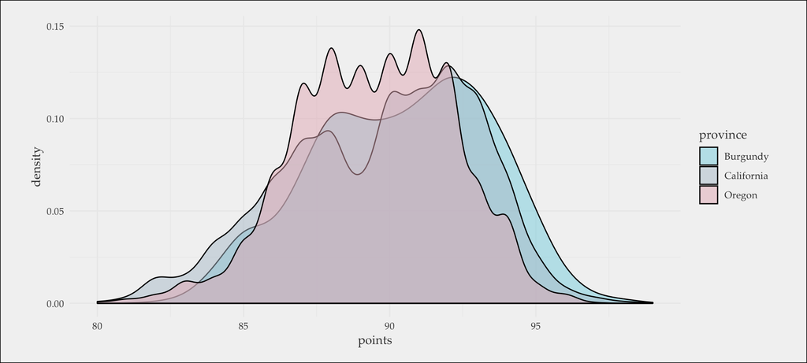

## Generally more for your money

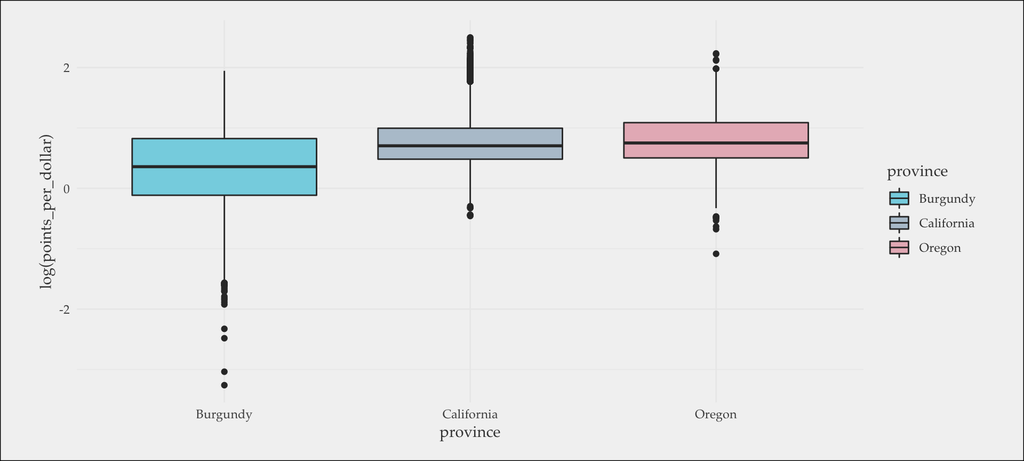

## Average points per year for Pinot Noir

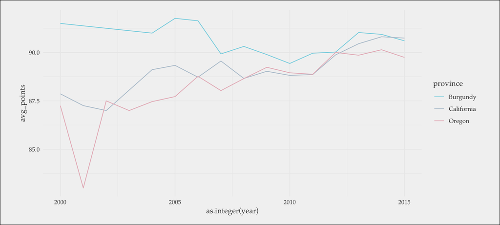

## Points per $$ for Pinot Noir

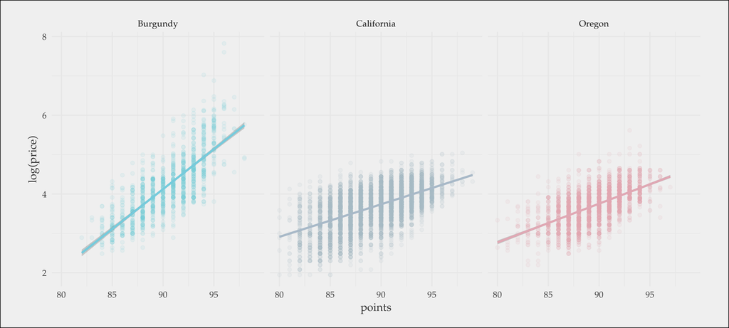

## More pricing power than California

Increases in points affect wines from the different regions differently.

- For **Burgundy**, a 1 point ratings increase leads to a **22.47%** increase in price.
- For **California**, a 1 point ratings increase leads to a **8.62%** increase in price.
- For **Oregon**, a 1 point ratings increase leads to a **10.35%** increase in price.

## Pricing power by flavor

- For Oregon Pinots with notes of **fruit**, a 1 point ratings increase leads to a **10.03%** increase in price.
- For Oregon Pinots with notes of **chocolate**, a 1 point ratings increase leads to a **11.52%** increase in price.
- For Oregon Pinots with notes of **tart**, a 1 point ratings increase leads to a **9.25%** increase in price.

## Pricing power by type of berry

- For Oregon Pinots with notes of **cherry**, a 1 point ratings increase leads to a **11.45%** increase in price.
- For Oregon Pinots with notes of **blackberry**, a 1 point ratings increase leads to a **11.75%** increase in price.
- For Oregon Pinots with notes of **strawberry**, a 1 point ratings increase leads to a **10.4%** increase in price.

## Summary

Oregon Pinot Noir…

1. Is fruit forward, with hints of chocolate and berries
2. Has lower overall variance in quality
3. Has been rising in quality over time
4. Has more pricing power than California
5. Is the best bang for your buck

Recommendations:

1. Work to retain and grow status of Willamette Valley globally
2. Smaller wineries can overcome status/recognition with targeted flavor profiles

## Thank you!!

…and we’re definitely better than Texas.

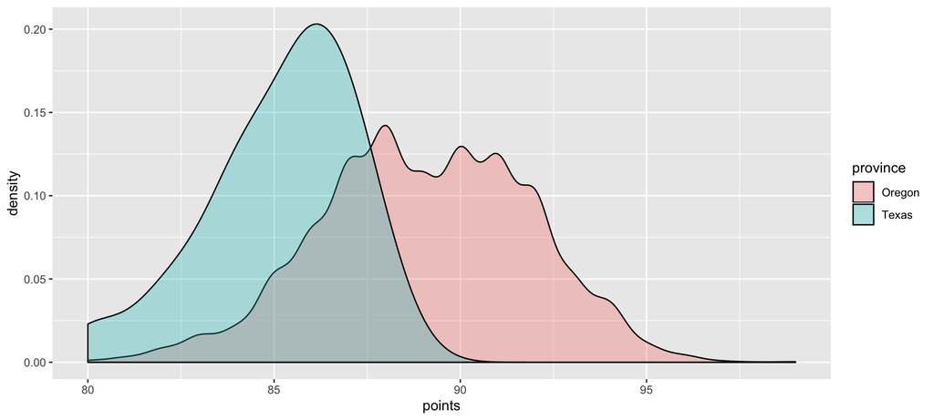

## Quality Oregon Pinots under $50

| title | points | price | BFYB |
| --- | --- | --- | --- |
| Sineann 2015 TFL Pinot Noir (Willamette Valley) | 96 | 30 | 3.2 |
| Scott Paul 2009 Dix Pinot Noir (Dundee Hills) | 96 | 40 | 2.4 |
| Sineann 2014 Wy’east Pinot Noir (Columbia Gorge (OR)) | 95 | 36 | 2.6 |
| Sineann 2015 Wy’east Pinot Noir (Columbia Gorge (OR)) | 95 | 36 | 2.6 |
| Alloro 2014 Estate Riservata Pinot Noir (Chehalem Mountains) | 95 | 45 | 2.1 |
| Domaine Drouhin 1999 Louise Drouhin Pinot Noir (Oregon) | 95 | 45 | 2.1 |
| Aberrant Cellars 2014 Gran Moraine Vineyard Pinot Noir (Willamette Valley) | 95 | 45 | 2.1 |
| Winderlea 2014 Weber Vineyard Pinot Noir (Dundee Hills) | 95 | 48 | 2.0 |

## Links

- https://github.com/jamesonwatts/Talks/tree/master/Data-Science-of-Wine
- https://www.kaggle.com/zynicide/wine-reviews
- https://www.tidyverse.org
- https://www.tidytextmining.com/